# Report Application Jobcode 28/2018

Sebastian Ginzel

26 Oktober 2018

## Introduction

The dataset presented contains count data from an unknown source. The basis are 4 replicates, taken at two different times (August and December) from the same individual. Each row contain absolute count data of an isoform and the counts of a malignant isoform. We will assume that the data is absolute count data and not a normalized measure, such as RPKM from an RNA-Seq experiment. This script will attempt to find isoforms, that show significant changes in malignant counts between the two months using the inverted beta-binomial test by [Pham et al].

First I setup the environment needed for the analysis. Next I will load, clean and explore the data before using the ibb.test method to find significantly changed isoforms. This method uses the inverted beta-binomial model in count data, usually applied to proteomics data. Compare to other count-based tests this allows us to calculate the shift in malignant counts, while taking the total number of counts into account.

## Environment

Let’s make sure we have the proper environment setup. The repository contains a packrat environment, that should be loaded before we proceed. It includes the local_cran folder as a repository to install from.

To do this we first have to download the IBB package from oncoproteomics, that we are going to use later for the DE analysis.

```r
if (!dir.exists("./local_cran")) dir.create("./local_cran")
if (!require("ibb")){
  if (!file.exists("./local_cran/ibb.tar.gz")){
    ibbarchive = file.path(".", "local_cran", "ibb.tar.gz")
    ibb.conf = read.dcf("./ibb.dcf", all=T)
    stopifnot(R.version$os == ibb.conf$os || as.integer(R.version$major) < 3)
    download.file(ibb.conf$url, ibbarchive)
    untar(ibbarchive, exdir = "./local_cran")
    install_local("ibb")
  }
}
```

```r
require(ibb, quietly = T)
require(magrittr, quietly = T)
require(ggplot2, quietly = T)
require(multtest, quietly = T)
require(ComplexHeatmap, quietly = T)
require(VennDiagram, quietly = T)
require(writexl, quietly = T)
source("helpers.R")

# Threads to use as part of the ibb.test function
NTHREADS = 7
```

## Load data

```r
tbl = read.table("./raw_data.tsv", sep="\t", header=T) %>% as.matrix
# lets add row names, so we can later track the filtered results back to the raw data - which is difficult just using indexes
rownames(tbl) = 1:nrow(tbl) %>% as.hexmode %>% format(.,width=4)
malig.cols = colnames(tbl) %>% grepl(pattern = "m$", x = .)
total.cols = colnames(tbl) %>% grepl(pattern = "t$", x = .)
decem.cols = colnames(tbl) %>% grepl(pattern = "^December", x = .)
augus.cols = colnames(tbl) %>% grepl(pattern = "^August", x = .)
```

## Data Exploration

Let us first look at some simple statistics to get an idea of the dataset.

```r
summary(tbl)
```

```
##    August_1m         August_2m         August_3m         August_4m
##  Min.   :   37.0   Min.   :   36.0   Min.   :   38.0   Min.   :   40.0
##  1st Qu.:   75.0   1st Qu.:   73.0   1st Qu.:   77.0   1st Qu.:  121.0
##  Median :  151.0   Median :  146.0   Median :  155.0   Median :  161.0
##  Mean   :  375.6   Mean   :  354.6   Mean   :  358.8   Mean   :  417.2
##  3rd Qu.:  303.0   3rd Qu.:  293.0   3rd Qu.:  272.0   3rd Qu.:  343.0
##  Max.   :26634.0   Max.   :50147.0   Max.   :33747.0   Max.   :59658.0
##  NA's   :15186     NA's   :14532     NA's   :15136     NA's   :15013
##   December_1m       December_2m       December_3m       December_4m
##  Min.   :   41.0   Min.   :   43.0   Min.   :   34.0   Min.   :   35.0
##  1st Qu.:   83.0   1st Qu.:  130.0   1st Qu.:   68.0   1st Qu.:   70.0
##  Median :  166.0   Median :  173.0   Median :  136.0   Median :  141.0
##  Mean   :  425.4   Mean   :  447.1   Mean   :  384.3   Mean   :  384.9
##  3rd Qu.:  333.0   3rd Qu.:  390.0   3rd Qu.:  307.0   3rd Qu.:  283.0
##  Max.   :80518.0   Max.   :40028.0   Max.   :37610.0   Max.   :49571.0
##  NA's   :14092     NA's   :14266     NA's   :12245     NA's   :12549
##    August_1t            August_2t            August_3t
##  Min.   :-9.223e+18   Min.   :-9.223e+18   Min.   :-9.223e+18
##  1st Qu.: 1.748e+03   1st Qu.: 1.689e+03   1st Qu.: 1.731e+03
##  Median : 3.788e+03   Median : 3.493e+03   Median : 3.620e+03
##  Mean   :       Inf   Mean   :       Inf   Mean   :       Inf
##  3rd Qu.: 8.118e+03   3rd Qu.: 7.336e+03   3rd Qu.: 7.793e+03
##  Max.   :       Inf   Max.   :       Inf   Max.   :       Inf
##  NA's   :15186        NA's   :14532        NA's   :15136
##    August_4t           December_1t          December_2t
##  Min.   :-9.223e+18   Min.   :-9.223e+18   Min.   :-9.223e+18
##  1st Qu.: 1.596e+03   1st Qu.: 1.836e+03   1st Qu.: 1.734e+03
##  Median : 3.415e+03   Median : 4.163e+03   Median : 3.771e+03
##  Mean   :       Inf   Mean   :       Inf   Mean   :       Inf
##  3rd Qu.: 7.132e+03   3rd Qu.: 9.251e+03   3rd Qu.: 7.885e+03
##  Max.   :       Inf   Max.   :       Inf   Max.   :       Inf
##  NA's   :15013        NA's   :14092        NA's   :14266
##   December_3t          December_4t
##  Min.   :-9.223e+18   Min.   :-9.223e+18
##  1st Qu.: 1.706e+03   1st Qu.: 1.609e+03
##  Median : 3.976e+03   Median : 3.712e+03
##  Mean   :       Inf   Mean   :       Inf
##  3rd Qu.: 9.101e+03   3rd Qu.: 7.868e+03
##  Max.   :       Inf   Max.   :       Inf
##  NA's   :12245        NA's   :12549
```

## Data Cleaning

There are a lot of NA values - which were lost by the logistic partner. We will treat these data points as absent, resulting in 0 count. Furthermore, we will remove isoforms that only contain 0 total counts.

There are negative and infinite values in the table as well. Negative counts do not make sense for absolute count data, infinite values may be introduced by some kind of oversaturation. Measures with negative values will be set to 0 and infinite values will be treated as missing data.

I will also perform missing value imputation, to make sure most of the dataset is utilized. There are varying the degrees of missing observations - some isoforms are only found in 1 replicate while others are present in 3. I will perform a missing value imputationfor all isoforms that have evidence in 2 or more replicates. All other isoforms (those only supported by one replicate) will be discarded.

To impute missing value I will use a simple averging approach, because it is simple and easy to reproduce. There are other missing value imputation methods out there, but without more information about the experimental setup this may do more harm than good.

```r
do_clean <- function(mtrx){
  nrowbefore = nrow(mtrx)
  mtrx = apply(mtrx, MARGIN = 2, function(x){
    x[is.infinite(x)] = NA#max(x[is.finite(x)])
    x[x < 0] = 0
    x
  })
  # need at least 2 replicates and total counts have to be available
  valid.replicates = apply(mtrx[,augus.cols & total.cols], 1, function(x){ sum(!is.na(x)) }) >= 2 & # at least 2 replicates in august
                     apply(mtrx[,decem.cols & total.cols], 1, function(x){ sum(!is.na(x)) }) >= 2 & # at least 2 replicates in december
                     apply(mtrx[,augus.cols & total.cols], 1, function(x){ any(x > 0) })          & # any total data in august > 0
                     apply(mtrx[,decem.cols & total.cols], 1, function(x){ any(x > 0) })            # any totol data in december > 0
  mtrx = mtrx[valid.replicates,]
  ## missing value imputation by averaging
  mtrx = apply(mtrx, 1, function(isoform){
    # average over missing value for august
    isoform[augus.cols & malig.cols & is.na(isoform)] = mean(isoform[augus.cols & malig.cols & !is.na(isoform)]) %>% as.integer
    isoform[augus.cols & total.cols & is.na(isoform)] = mean(isoform[augus.cols & total.cols & !is.na(isoform)]) %>% as.integer
    isoform[decem.cols & malig.cols & is.na(isoform)] = mean(isoform[decem.cols & malig.cols & !is.na(isoform)]) %>% as.integer
    isoform[decem.cols & total.cols & is.na(isoform)] = mean(isoform[decem.cols & total.cols & !is.na(isoform)]) %>% as.integer
    isoform
  }) %>% t
  sprintf("%.2f%% isoforms are valid for analysis.\n", round(nrow(mtrx)/nrowbefore,3)*100) %>% cat
  mtrx
}
tbl.clean = do_clean(tbl)
```

```
## 24.80% isoforms are valid for analysis.
```

### Data Exploration Clustering

To have a look at the consistency of the replicates we generate a bi-plot of the malignant frequency per sample. If all replicates are structured the same, we expect the bi-plot to show us one or two clusters. One cluster containing all replicates would indicate only little support for actual difference between the groups. Two clusters, that seperate August and December would show us, that there are differences we can discovery using a DEG method. In case there are more clusters, or the principal component do not seperate August and December we may need to adjust our analysis.

```r
# calcluate malignant frequncy per replicate
malig.frac = (t(tbl.clean[,malig.cols]) * 1.0/colSums(tbl.clean[,total.cols])) %>% t
colnames(malig.frac) %<>% gsub("August", "Aug", x = .) %>% gsub("December", "Dec", x = .) # for better plotting
pca = prcomp(t(malig.frac))
summary(pca)
```

```
## Importance of components%s:
##                              PC1       PC2       PC3       PC4       PC5
## Standard deviation     0.0005699 0.0003686 0.0002062 0.0001783 0.0001583
## Proportion of Variance 0.5482900 0.2293100 0.0718000 0.0536600 0.0422800
## Cumulative Proportion  0.5482900 0.7775900 0.8493900 0.9030500 0.9453300
##                              PC6       PC7      PC8
## Standard deviation     0.0001423 0.0001102 1.24e-19
## Proportion of Variance 0.0341600 0.0205100 0.00e+00
## Cumulative Proportion  0.9794900 1.0000000 1.00e+00
```

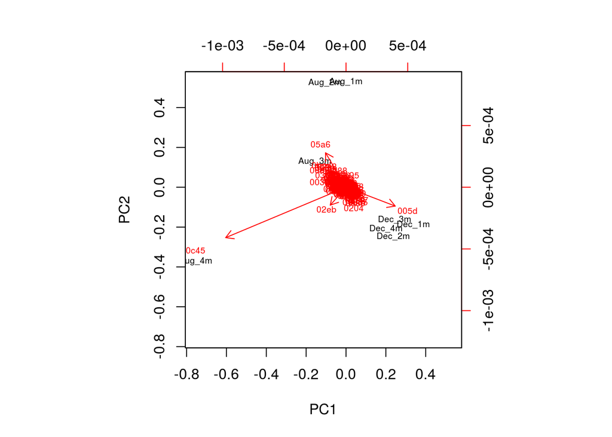

```r
# The frequncies can be really small, so R will warn us that it is unable to plot very short arrows
suppressWarnings(biplot(pca, cex=0.6))
```

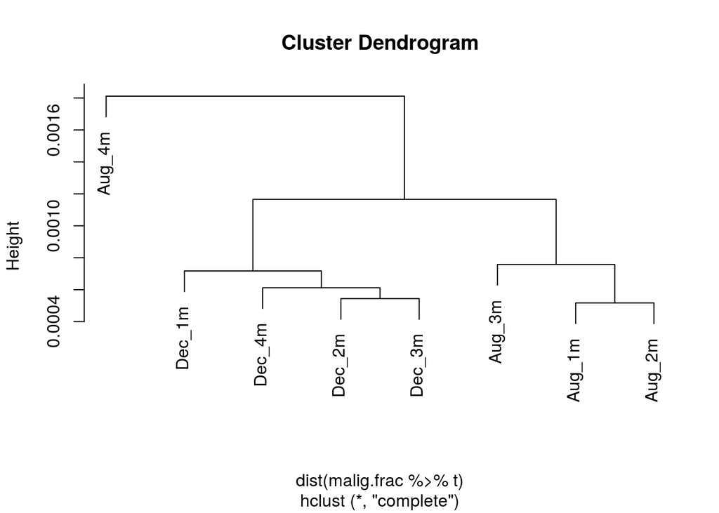

```r
plot(hclust(dist(malig.frac %>% t)))
```

```r
is.outlier = (colnames(tbl) %>% grepl("August_4[mt]$", .))
```

The biplot (and the equivalent hierarchical clustering) show that the December replicates are relatively consistend - the first 2 principal components explain 78% of the variance, so this biplot is not a bad embedding. Principal component 2 seperates August and December quite well, so we can expect to find significantly different isoforms.

The August_4m replicate however is seperated by the second principal component from the other August replicates (differnt signs), suggesting that it may introduce more variance than it should.

As we have no biological or experimental data available for further interpretation, we will just keep this in mind for later to have a look at.

## DE Analysis

Since the pairs are not matched, we need to aggregate the replicates. We do this using `mean` - aggregating the evidence for isoforms from all samples.

The ibb.test method is quite computational expensive, so we will use the `do.cache` method from the helpers.R script, to provide some simple caching for us.

```r
do_ibb_test <- function(mtrx, mcols, tcols, agg.method = rowMeans, ...){
  augcol = grepl("August", colnames(mtrx))
  deccol = grepl("December", colnames(mtrx))
  tbl.test = data.frame(
    august.malig = agg.method(mtrx[,mcols & augcol]),
    decmbr.malig = agg.method(mtrx[,mcols & deccol]),
    august.total = agg.method(mtrx[,tcols & augcol]),
    decmbr.total = agg.method(mtrx[,tcols & deccol])
  )
  ibb.result = do.cache(FUN = ibb.test,
                      x =  tbl.test[,1:2],
                      tx = tbl.test[,3:4],
                      group = c("August", "December"),
                      n.threads = NTHREADS, ...
                      ) %>% as.data.frame
  rownames(ibb.result) = rownames(tbl.test)
  pval.correction = multtest::mt.rawp2adjp(ibb.result$p.value, c("Bonferroni", "BH"))
  ibb.result = cbind(ibb.result, pval.correction$adjp[order(pval.correction$index),])
  ibb.result$rawp = NULL
  ibb.result
}
ibb.result = do_ibb_test(tbl.clean, malig.cols, total.cols, cache.file = "ibb_imputed.RData", cache.force = F)
```

```
## Reading cached result ibb_imputed.RData...DONE
```

```r
ibb.result.nooutlier = do_ibb_test(tbl.clean[,!is.outlier], malig.cols[!is.outlier], total.cols[!is.outlier], cache.file = "ibb_imputed_nooutlier.RData", cache.force = F)
```

```
## Reading cached result ibb_imputed_nooutlier.RData...DONE
```

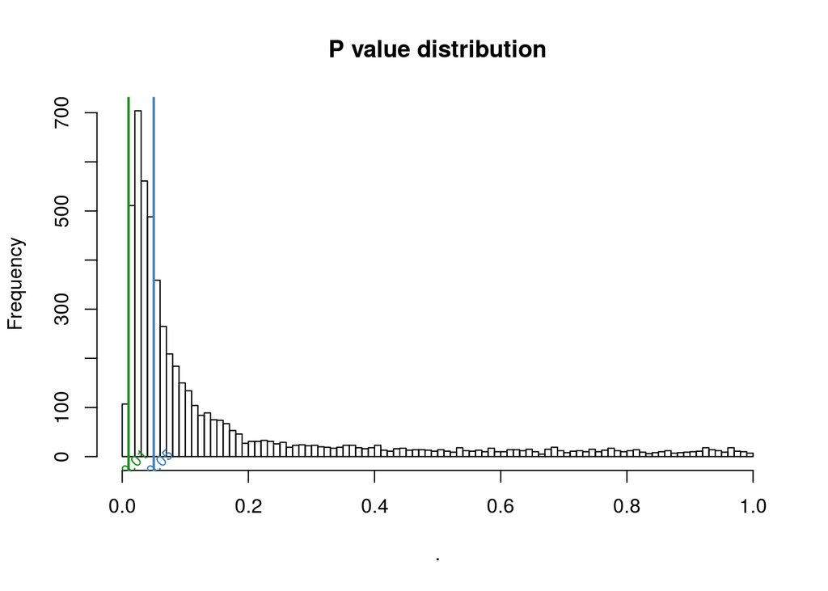

```r
ibb.result$p.value %>% hist(., breaks=seq(0,1, by=0.01), main = "P value distribution")
abline(v=0.05, lwd=2, col="steelblue")
text(x=0.05, y=0, "0.05", adj = c(0.5,1.2), cex=0.8, col="steelblue", srt=45)
abline(v=0.01, lwd=2, col="forestgreen")
text(x=0.01, y=0, "0.01", adj = c(0.5,1.2), cex=0.8, col="forestgreen", srt=45)
```

The p-values are not evenly distributed, which is more evidence for the previous conclusion we drew from the biplot, that we can find significant changes. However the p-value distribution peaks around 0.03 and then falls off towards 0, which may be a property of the test statistic and the reason why multiple testing correction does not yield any significant isoforms.

With information about the biological background of the data and the isoform transcripts, we could further look into investigating how house keeping isoforms behave in the test and do a consistency check, because these should not be significantly different between August and December. For now we will chose 0.01 as our significance cutoff as it seems unreasonable, that more than 1000 isoforms are significantly different.

#### Volcano plot

We can also have a look at the fold change and p-value distribution using a volcano plot.

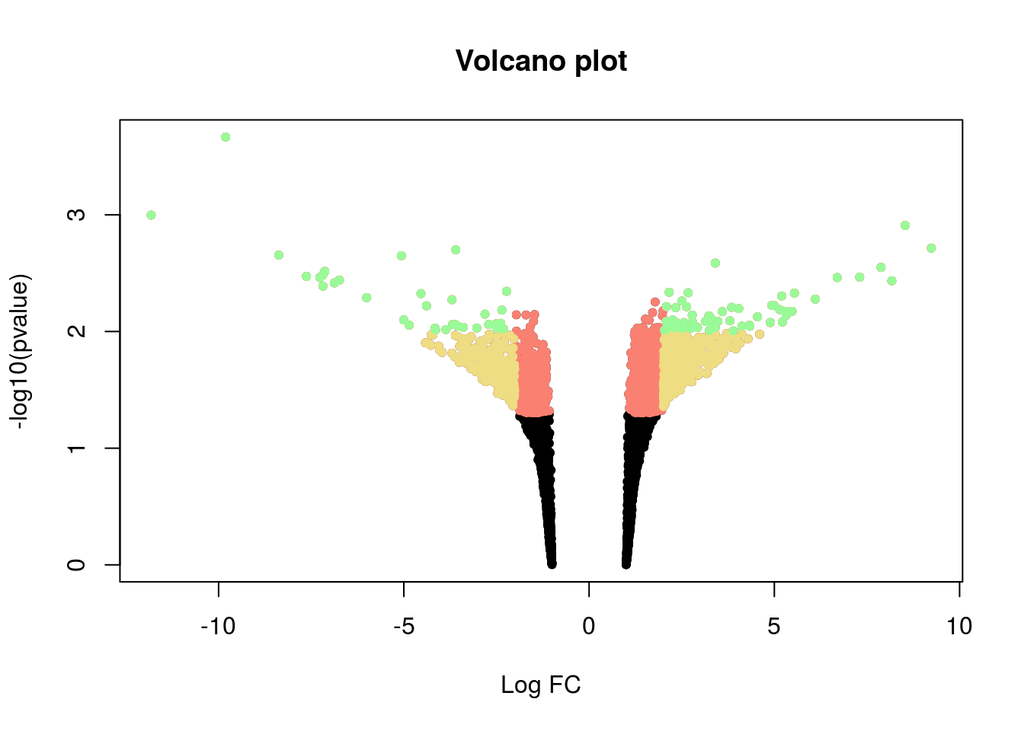

```r
{
  with(ibb.result, plot(fc , -log10(p.value), xlab="Log FC", ylab="-log10(pvalue)", pch=20, main = "Volcano plot"))
  with(subset(ibb.result, abs(fc)>1 & p.value < 0.05), points(fc, -log10(p.value), col="salmon", pch=20))
  with(subset(ibb.result, abs(fc)>2 & p.value < 0.05), points(fc, -log10(p.value), col="lightgoldenrod", pch=20))
  with(subset(ibb.result, abs(fc)>2 & p.value < 0.01), points(fc, -log10(p.value), col="palegreen", pch=20))
}
```

All siginficant fold changes > 1 are marked red, they are subsequently marked yellow if they exceed fold change of 2. Those that exceed a fold change of 2 and the p-value threshold of 1% are marked green.

From this plot we can see that the significant changes are more or less evenly up/down regulated. The fold changes themselves are also within similar orders of magnitude, which otherwise may indicate a very strong singular effect.

#### Venndiagram with/without outliers

To see how much influence the outliers have on the overall result we can show a venn diagram of the common/exclusive results.

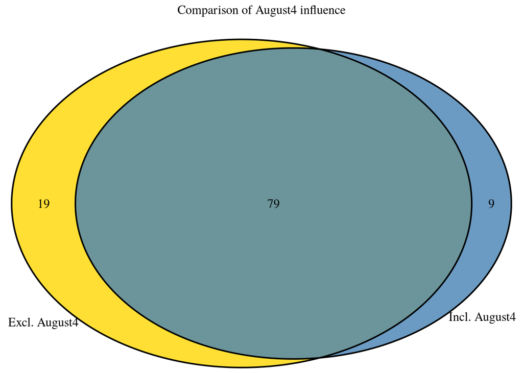

```r
grid.newpage()
list(
  "Incl. August4" = subset(ibb.result          , p.value<0.01 & abs(fc) > 2) %>% rownames(),
  "Excl. August4" = subset(ibb.result.nooutlier, p.value<0.01 & abs(fc) > 2) %>% rownames()
) %>% venn.diagram(., filename = NULL, main = "Comparison of August4 influence", alpha=0.8, fill=c("steelblue", "gold"), margin=.0) %>% grid.draw(.)
```

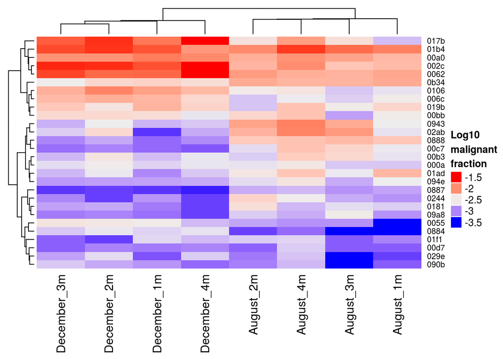

```r
sigset1 = subset(result, p.value < 0.01 & abs(fc)>2)$name
sigset2 = subset(result, p.value.nooutlier < 0.01 & abs(fc.nooutlier)>2)$name
difference.outliers = c(setdiff(sigset1, sigset2),setdiff(sigset2, sigset1))
(t(tbl.clean[difference.outliers,malig.cols])*(1/colSums(tbl.clean[difference.outliers,total.cols]))) %>% t %>% log10 %>% Heatmap(., clustering_method_columns="single", row_names_gp = gpar(fontsize=8), name = "Log10\nmalignant\nfraction")
```

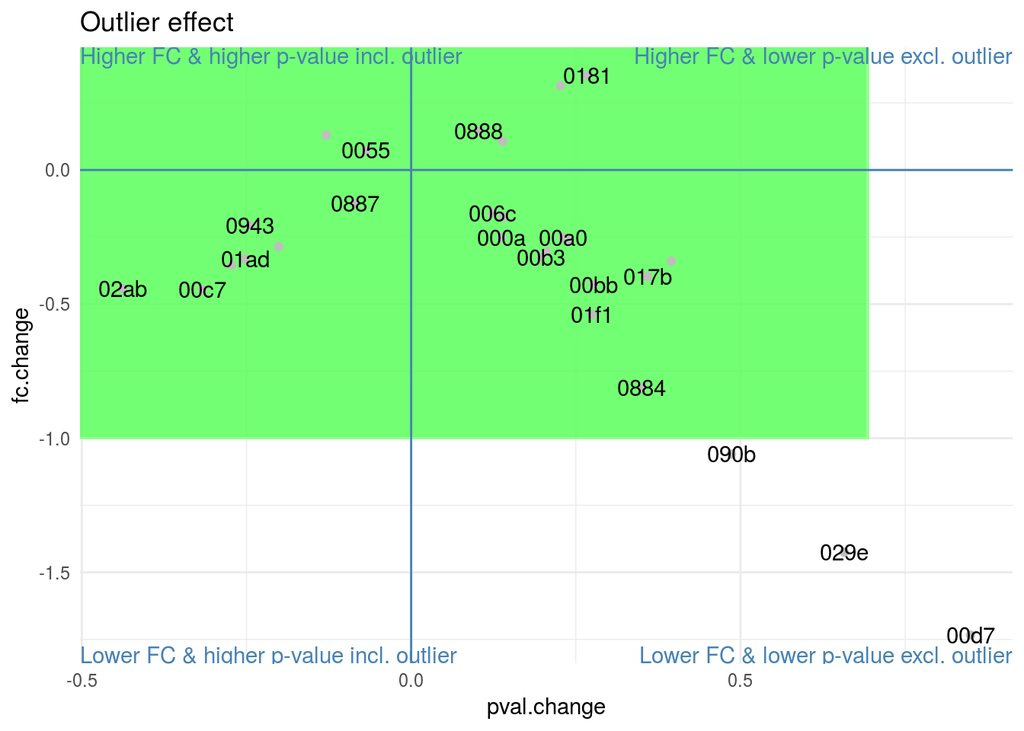

```r
outlier.effect = subset(result, name %in% difference.outliers)
outlier.effect$fc.change = with(outlier.effect, fc-fc.nooutlier)
outlier.effect$pval.change = with(outlier.effect, log2(p.value/p.value.nooutlier))
g = ggplot(data = outlier.effect, aes(x=pval.change, y=fc.change, label=name)) +
  geom_rect(xmin=log(0.5), xmax=log(2), ymin=-1, ymax=1, color="palegreen", alpha=0.1, fill = rgb(0.43,1,0.43,0.5)) +
  geom_point(col="grey") +
  geom_text(check_overlap = T) +
  annotate("text",  x=-Inf, y = Inf, label = "Higher FC & higher p-value incl. outlier", vjust="inward", hjust="inward", col="steelblue")+
  annotate("text",  x=-Inf, y = -Inf, label= "Lower FC & higher p-value incl. outlier", vjust="inward", hjust="inward", col="steelblue")+
  annotate("text",  x=Inf, y = -Inf, label = "Lower FC & lower p-value excl. outlier", vjust="inward", hjust="inward", col="steelblue")+
  annotate("text",  x=Inf, y = Inf, label  = "Higher FC & lower p-value excl. outlier", vjust="inward", hjust="inward", col="steelblue")+
  geom_hline(yintercept = 0, col="steelblue")+
  geom_vline(xintercept = 0, col="steelblue")+
  ggtitle("Outlier effect")+
  theme_minimal()
plot(g)
```

Overall the experiment and statistic looks robust against inter-replicate variance, showing that a coreset of 79 isoforms is not influenced by the presence/absence of the August4 replicate.

However 19 are gained by excluding August4 and 9 gained by including them. When we look at the pvalue and fold change drift, that is explained by Aug4 we can see that overall there is little change. The fold change for most measures stays within +/- 1 and the p-value varies between 0.005 and 0.02 - given that 0.02 is still well under the common p-value cutoff of 5% this is tolerateable (tolerable area marked in green).

We create a report in excel format which is a lot more convienient to most end-users. This will also include information about how many replicates support the isoform in the raw data.

|  | p.value | fc | Bonferroni | BH | name | is.significant | is.significant.without.outlier | august.replicates.supporting | december.replicates.supporting | note |
| --- | --- | --- | --- | --- | --- | --- | --- | --- | --- | --- |
| 0001 | 0.0093430 | 1.303508 | 1 | 0.1146949 | 0001 | TRUE | FALSE | 4 | 4 |  |
| 0003 | 0.0083760 | 2.345377 | 1 | 0.1146949 | 0003 | TRUE | TRUE | 4 | 4 |  |
| 0004 | 0.0051224 | -6.002205 | 1 | 0.1146949 | 0004 | TRUE | TRUE | 4 | 4 |  |
| 0006 | 0.0086434 | 2.284761 | 1 | 0.1146949 | 0006 | TRUE | TRUE | 4 | 4 |  |
| 0009 | 0.0080045 | 1.620011 | 1 | 0.1146949 | 0009 | TRUE | FALSE | 4 | 4 |  |
| 000a | 0.0105479 | 2.414152 | 1 | 0.1146949 | 000a | FALSE | TRUE | 4 | 4 |  |
| 000b | 0.0081930 | 2.083490 | 1 | 0.1146949 | 000b | TRUE | TRUE | 4 | 4 |  |
| 000c | 0.0073328 | 3.234414 | 1 | 0.1146949 | 000c | TRUE | TRUE | 4 | 4 |  |
| 000d | 0.0065516 | -2.355139 | 1 | 0.1146949 | 000d | TRUE | TRUE | 4 | 4 |  |
| 000f | 0.0071016 | -2.810154 | 1 | 0.1146949 | 000f | TRUE | TRUE | 4 | 4 |  |
| 0011 | 0.0081967 | 3.475039 | 1 | 0.1146949 | 0011 | TRUE | TRUE | 4 | 4 |  |
| 0012 | 0.0025919 | 3.408785 | 1 | 0.1146949 | 0012 | TRUE | TRUE | 4 | 4 |  |
| 0013 | 0.0049596 | 5.199510 | 1 | 0.1146949 | 0013 | TRUE | TRUE | 4 | 4 |  |
| 0016 | 0.0081788 | -1.497233 | 1 | 0.1146949 | 0016 | TRUE | FALSE | 4 | 4 |  |
| 0017 | 0.0093486 | 2.326789 | 1 | 0.1146949 | 0017 | TRUE | TRUE | 4 | 4 |  |
| 0018 | 0.0012318 | 8.533247 | 1 | 0.1146949 | 0018 | TRUE | TRUE | 4 | 4 |  |
| 001b | 0.0076626 | 3.281629 | 1 | 0.1146949 | 001b | TRUE | TRUE | 4 | 4 |  |
| 001e | 0.0094073 | 2.744672 | 1 | 0.1146949 | 001e | TRUE | TRUE | 4 | 4 |  |
| 0020 | 0.0091972 | 1.873523 | 1 | 0.1146949 | 0020 | TRUE | FALSE | 4 | 4 |  |
| 0023 | 0.0054734 | 2.508225 | 1 | 0.1146949 | 0023 | TRUE | TRUE | 4 | 4 |  |
| 0025 | 0.0074728 | 4.547330 | 1 | 0.1146949 | 0025 | TRUE | TRUE | 4 | 4 |  |
| 0026 | 0.0046102 | 2.162110 | 1 | 0.1146949 | 0026 | TRUE | TRUE | 4 | 4 |  |
| 0028 | 0.0067619 | 3.598424 | 1 | 0.1146949 | 0028 | TRUE | TRUE | 4 | 4 |  |
| 002a | 0.0092175 | 1.454997 | 1 | 0.1146949 | 002a | TRUE | FALSE | 4 | 4 |  |
| 002c | 0.0066420 | 1.997728 | 1 | 0.1146949 | 002c | TRUE | TRUE | 4 | 4 |  |
| 0032 | 0.0045228 | -2.225463 | 1 | 0.1146949 | 0032 | TRUE | TRUE | 4 | 4 |  |
| 003c | 0.0094498 | 1.849250 | 1 | 0.1146949 | 003c | TRUE | FALSE | 4 | 4 |  |
| 0042 | 0.0078219 | 1.522636 | 1 | 0.1146949 | 0042 | TRUE | FALSE | 4 | 4 |  |
| 0043 | 0.0047354 | -4.538548 | 1 | 0.1146949 | 0043 | TRUE | TRUE | 4 | 4 |  |
| 0046 | 0.0062010 | 3.848333 | 1 | 0.1146949 | 0046 | TRUE | TRUE | 4 | 4 |  |

[output cut: 92 more lines]

## Summary

The integrity check revealed that replicates August_4 seperates from the other August replicates by a principal component. Making this replicate a possible outliers, which should be accounted for in the analysis.

## References

[Pham et al] Pham TV, Jimenez CR (2012) An accurate paired sample test for count data. Bioinformatics, 28(18):i596-i602.